# Ecological Conditions Favoring Budding in Colonial Organisms under Environmental Disturbance

## Introduction

Dispersal distance varies widely among organisms. Dispersal determines the genetic structure of the meta-population and influences the evolution of individual characteristics such as mortality, reproductive efforts, sex allocation and altruism [1]–[3]. Since dispersal is a costly activity, why organism disperse has become an important issue in evolutionary ecology [4], [5]. In the pioneering meta-population model of Hamilton and May (1977) it was shown that dispersal can evolve even when the dispersal cost is so high that nearly all dispersers are destined to die. Subsequent studies identified specific factors that favor dispersal over non-dispersal, such as the avoidance of competition among relatives and inbreeding [1], [2]. Disturbances such as predation, drought and flooding are regarded as important general triggers of dispersal, encouraging organisms to hedge the risks [6].

However, many organisms do not disperse long distances. For example, some organisms often adopt an “budding” strategy, where a colony splits into two or more parts which subsequently move away from each other. The budding by clones, buds, or propagules has been studied theoretically and experimentally from the viewpoint of the evolution of altruism and sex ratio [7]–[9]. However, those studies did not focus on the difference in dispersal distance, while in many real organisms the budding strategy is typically characterized by shorter-range dispersal in comparison to non-budding dispersal. Contrary to the conventional view, organisms reproducing by budding often survive in environments undergoing frequent disturbance. For example, many invasive clonal plants that are specialists of disturbed habitats predominantly use vegetative reproduction, despite retaining the seed-producing capability that would enhance their spread [10], [11]. New colonies of branching gorgonian coral (*Plexaurella* sp.) exposed to waves are predominantly founded by fragments of broken branches, rather than by inseminated gametes that can migrate long distances [12]. In some invasive ants, such as *Linepithema humile* (the Argentine ant) and *Wasmannia auropunctata* (the tiny fire ant), winged queens do not engage in nuptial (dispersal) flights. Instead they mate within or near natal nests, and new colonies are founded by colony-splitting (fission or budding), in which queens search for a new nest site on foot, accompanied by some workers [13], [14]. These invaders are recognized as specialists of disturbed habitats [13], [15], [16]. However, the ecological conditions favoring budding remain obscure.

https://doi.org/10.1371/journal.pone.0091210.t001

However, Nakamaru et al. did not clarify the effect of spatial structure and the life history on the above-mentioned advantage. For each colony, they specifically assumed that growth is logistic and that death rate is a negative exponential function of colony size. However, other survivorship patterns and other growth functions are possible in nature. The authors failed in their quest for a mathematical model that could accommodate relatively complicated assumptions and therefore could not obtain analytical results. These drawbacks have precluded a precise understanding of the adaptive significance of budding. To more generally understand the ecological conditions that induce budding dispersal, here we investigate the characteristics of an organism's life history functions, such as survivorship and colony growth, that favor budding dispersal under disturbance.

We adopt the general view that life history parameters (survival, growth and reproduction functions) directly determine the evolved dispersal strategy [18], [19]. Environmental conditions, such as spatial structure and disturbance, influence the above parameters in a complicated manner through environment vs. phenotype interactions. In this paper we make a simple generalized assumption that is applicable to colonial organisms adopting similar resource allocation strategies. We first focus on colonial life history using a model without spatial structure, called the baseline model. This model assumes discrete colony size, assigning different death and growth probabilities to each colony size. Under this assumption, we can construct discrete equations or a matrix model in the baseline model that permit exact solutions. We clarify the effects of life histories or demographics (such as survivorship and growth rate) on the competition between the two strategies, i.e. budding vs. non-budding. We also examine the conditions under which budding is advantageous over non-budding when realistic and possible assumptions are added to the baseline model.

## Methods and Results

### Model 1: The baseline model in the completely mixed population

It is common that an individual is assumed to be a basic unit in the agent-based simulation model. In contrast, here the basic unit in our agent-based simulation model is the clonal (super) organism or the colony of individuals, and the model is called the colony-based model. Gardner and Grafen (2009) proved that there is no mathematical difference between an individual organism and a clonal group if social groups have no intracolonial conflicts [20].

https://doi.org/10.1371/journal.pone.0091210.g001

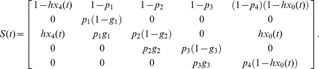

Let *x*<sub>0</sub>(*t*) be the density of empty sites at time *t* and *x<sub>i</sub>*(*t*) (*i* = 1, 2, 3 and 4) be the density of colonies of size *i* adopting the 2∶2 division strategy at time *t*, subject to Σ*<sub>i</sub> x<sub>i</sub>*(*t*) = 1. The values of *hx*<sub>4</sub>(*t*) in element (3, 1) and *hx*<sub>0</sub>(*t*) in element (3, 5) show that, when a size 4 colony divides, one of the two resulting size 2 colonies disperses to an empty site while the other remains in its natal habitat.

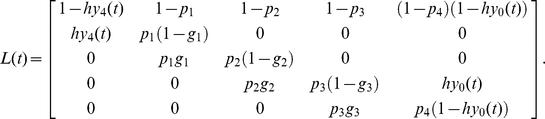

Let *y*<sub>0</sub>(*t*) be the density of empty sites at time *t* and *y<sub>i</sub>*(*t*) (*i* = 1, 2, 3 and 4) be the density of colonies of size *i* adopting the 1∶3 division strategy at time *t*, subject to Σ*<sub>i</sub> y<sub>i</sub>*(*t*) = 1. When a size 4 colony divides, the probability of the resulting size 1 colony successfully migrating to an empty site is determined by *hy*<sub>4</sub>(*t*) in element (2, 1), while the probability that the size 3 colony remains in its natal habitat is *hy*<sub>0</sub>(*t*) in element (4, 5).

### Results when all growth probabilities are one

#### Mathematical results of the colony size-structured matrix model.

Equation (6) can be rewritten as *p*<sub>2</sub>>1/(2−*p*<sub>1</sub>)≥1/2, indicating that colonies adopting the 2∶2 division strategy can overcome their 1∶3 counterparts when *p*<sub>2</sub> exceeds 0.5. Inequality (7) can be rewritten as *p*<sub>2</sub><1/(2−*p*<sub>1</sub>)≤1. Equations (6) and (7) also indicate that relatively high *p*<sub>2</sub> can favor colonies adopting the 2∶2 division strategy.

When *d*<sub>1</sub> = *d*<sub>2</sub> = *d*<sub>3</sub> = *d*<sub>4</sub>, i.e. the dynamics are size-independent, inequality (7) always holds. This result implies that, in size-independent dynamics, the 1∶3 division strategy is always advantageous over the 2∶2 division strategy.

To investigate whether inequalities (4) – (7) hold for any values of *p*<sub>1</sub>, *p*<sub>2</sub>, *p*<sub>3</sub> and *p*<sub>4</sub>, we conduct the numerical simulations of Eq. (D1) presented in appendix S4, and also run the colony-based simulations.

#### Simulation results of competition for empty sites between two reproductive strategies (2∶2 division and the 1∶3 division).

We conducted colony-based simulations based on the assumptions in the previous section. We assume 2,500 sites, either unoccupied or occupied by colonies adopting one of two reproductive strategies. Each parameter set was run 100 times.

Three forms of the baseline death probability function are considered in the simulations. Death type (i) assumes that *d*<sub>2</sub> = *d*<sub>3</sub> = *d*<sub>4</sub>. If *d*<sub>1</sub> is higher than the other rates, this function is similar to the exponential decreasing function adopted in Nakamaru et al. [17]. In death type (ii), the death probability function is a linear function of size, and defining *d*<sub>1</sub> and *d*<sub>4</sub> automatically determines *d*<sub>2</sub> and *d*<sub>3</sub>. In death type (iii), we assume that *d*<sub>1</sub> = *d*<sub>2</sub> = *d*<sub>3</sub>. If *d*<sub>1</sub> = *d*<sub>4</sub>, the four death probabilities are identical. In this scenario, we can investigate the size-independent ecological dynamics and compare them with the size-dependent dynamics.

https://doi.org/10.1371/journal.pone.0091210.g002

Now consider the scenario in which the death probability of a size 1 colony is prohibitively high. Once colonies adopting the 1∶3 division strategy have divided, the size 1 daughter colonies die out, while the size 3 colonies survive and mature. Colonies adopting the 2∶2 division strategy are not affected by the small survival chance of size 1 colonies, and both daughter colonies will likely survive.

Next, we assign a high death probability to a size 2 colony, and observe the effects on the ecological dynamics. Figure 1 B indicates that colonies adopting the 2∶2 division strategy can scarcely increase their numbers because most of the daughter colonies dies out before reaching maturity. Meanwhile, although new size 1 colonies also die out, the size 3 colonies can survive to maturity. Therefore, imposing a high death probability on size 2 colonies favors colonies adopting the 1∶3 division strategy. This discussion is supported by the competition conditions (Eqs. (6) and (7)).

### The results when all growth probabilities are less than one

The competition conditions are independent of the division rate *h*, but *h* does affect the viability conditions. In essence, small *h* restrains colony survival. The competition conditions are influenced by the survival and growth probabilities of size 1 and 2 colonies (see also inequalities (6) and (7)), but not by those of older colonies.

When *d*<sub>1</sub> = *d*<sub>2</sub> = *d*<sub>3</sub> = *d*<sub>4</sub> and *g*<sub>1</sub> = *g*<sub>2</sub> = *g*<sub>3</sub>, interpreted as no colony dynamics, inequality (11) is always upheld. This result implies that, in static colonies, the 1∶3 division strategy always confers survival at the expense of the 2∶2 division strategy.

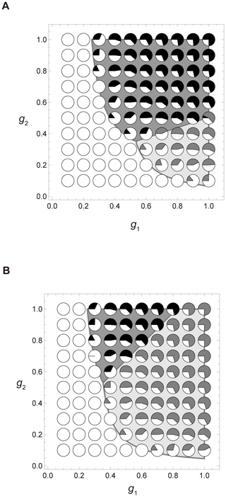

Figure 3. The *g*<sub>1</sub>-*g*<sub>2</sub> plot of simulated and theoretical results in a completely mixed population.

Simulations are iterated 6,250 times. Parameters are *d*<sub>2</sub> = *d*<sub>3</sub> = *d*<sub>4</sub> = 0.15, *h* = 1, *u* = 0. The horizontal and vertical axes represent *g*<sub>1</sub> ( = *g*<sub>3</sub>) and *g*<sub>2</sub>, respectively. Initial densities are *z*<sub>0</sub> = 0.6 and *x*<sub>1</sub> = *x*<sub>2</sub> = *x*<sub>3</sub> = *x*<sub>4</sub> = *y*<sub>1</sub> = *y*<sub>2</sub> = *y*<sub>3</sub> = *y*<sub>4</sub> = 0.05. More information is provided in the caption to Fig. 2. (A) *d*<sub>1</sub> = 0.35. (B) *d*<sub>1</sub> = 0.15.

https://doi.org/10.1371/journal.pone.0091210.g003

### Model 2 and results: Direct competition between a dispersing colony and settled colonies

Thus far, the model has assumed no direct competition between colonies; dispersing colonies avoid sites occupied by existing colonies, and seek unoccupied sites in which to settle. However, direct competition is the norm in nature. In this section, we examine the effect of direct competition imposed by dispersing colonies settling at new sites.

Competition is introduced to the baseline model with *g<sub>i</sub>* = 1. Once a colony has divided into two, one of the daughter colonies migrates from the natal colony site to a new site chosen randomly from the site population. If the site is empty, the dispersing colony settles there. If the site is occupied by another colony, the dispersing colony competes with the settled colony for the space. Let *w<sub>ij</sub>* be the probability that a dispersing colony of size *i* invades and annihilates a settled colony of size *j*. We investigate three types of direct competition: (i) *w<sub>ij</sub>* = 0.0, (ii) *w<sub>ij</sub>* = 1.0, (iii) *w<sub>ij</sub>* = 1 if *i*>*j*, *w<sub>ij</sub>* = 0.5 if *i* = *j*, and *w<sub>ij</sub>* = 0.0 if *i*<*j*. In situation (i), the settled colony can overcome the dispersing colony regardless of its size, and the dispersing colony dies out. In (ii), the dispersing colony always combats the settled colony, the settled colony dies out, and the dispersing colony occupies the site. Situation (iii) implies that a larger colony always overtakes a smaller one.

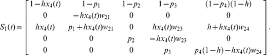

At equilibrium, *x** = (1, 0, 0, 0, 0)*<sup>t</sup>* is locally unstable when 2*p*<sub>2</sub>*p*<sub>3</sub> > *p*<sub>4</sub> + (1−*p*<sub>4</sub>)/*h* regardless of *w<sub>ij</sub>*, which corresponds to inequality (4).

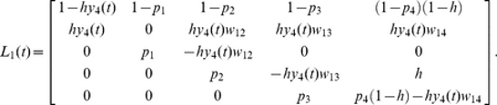

At equilibrium, *y** = (1, 0, 0, 0, 0)*<sup>t</sup>* is locally unstable when (1+*p*<sub>1</sub>*p*<sub>2</sub>)*p*<sub>3</sub> > *p*<sub>4</sub> + (1−*p*<sub>4</sub>)/*h* regardless of *w<sub>ij</sub>*, which corresponds to inequality (5).

Interestingly, the baseline model with *g<sub>i</sub>* = 1 and the direct competition model share the same local stability condition; an equilibrium in which all colonies become extinct. This arises because a newly-divided dispersing colony encountering many empty sites at equilibrium will more likely settle at a site not already occupied. In this situation, direct competition exerts little influence on the population dynamics.

To investigate the effect of direct competition among colonies adopting either reproductive strategy, we run the colony-based simulations under death type (i), which most strongly favors the 2∶2 division strategy among the three death categories. As shown in Figure 4, among the three categories of direct competition, the 2∶2 division strategy is most favored in category (ii).

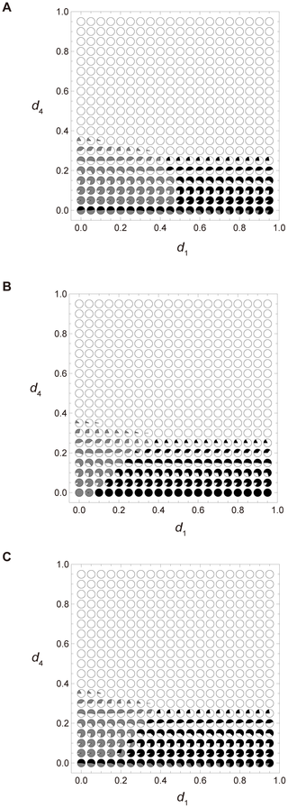

Figure 4. The *d*<sub>1</sub>-*d*<sub>4</sub> graph of the colony-based simulations in which a dispersing colony competes with settled colonies.

The horizontal and vertical axes represent *d*<sub>1</sub> and *d*<sub>4</sub>, respectively. Death type (i), in which *d*<sub>2</sub> = *d*<sub>3</sub> = *d*<sub>4</sub>, is assumed. Each pie chart shows the average densities of sites occupied by either of the two strategies, as well as the empty sites (open circles) after 5,000 iterations of (A) and (B) and after 20,000 iterations of (C) in 100 simulations. The black and gray portions of each circle indicate the average densities of sites occupied by colonies undertaking the 2∶2 division strategy and the 1∶3 division strategy, respectively. The open portion represents the average density of empty sites. Initial densities are *z*<sub>0</sub> = 0.6 and *x*<sub>1</sub> = *x*<sub>2</sub> = *x*<sub>3</sub> = *x*<sub>4</sub> = *y*<sub>1</sub> = *y*<sub>2</sub> = *y*<sub>3</sub> = *y*<sub>4</sub> = 0.05. The other parameters are: 2,500 sites, *u* = 0 and *h* = 1. (A) Direct competition (i), in which *w<sub>ij</sub>* = 0.0. (B) Direct competition (ii), in which *w<sub>ij</sub>* = 1.0. (C) Direct competition (iii), in which a bigger colony always combats a smaller one.

https://doi.org/10.1371/journal.pone.0091210.g004

Next, we discuss why direct competition category (ii), rather than category (i), confers advantage to the 2∶2 division strategy, focusing on the disadvantage of the 1∶3 division strategy in this scenario. The 1∶3 division strategy disperses a size 1 colony, while the larger colony remains at the site. Recall that, in this strategy, a size 3 colony matures more rapidly than a colony of size 1. In direct competition category (ii), a size 3 colony dies out, whereas a size 1 colony disperses and settles at a new site. Since a size 1 colony matures more slowly than a size 2 colony, the 2∶2 division strategy is advantageous over the 1∶3 division strategy. Conversely, in direct competition category (i), a size 3 colony can survive but a size 1 colony cannot colonize a new site. In this scenario, the 1∶3 division strategy is preferable.

### Model 3 and results: Spatial structure and environmental disturbance

In a previous section, we found that imposing death type (i) and the logistic growth of colonies favor the 2∶2 division strategy over the 1∶3 strategy when dispersing colonies seek and settle at unoccupied spaces in a completely mixed population. In this section, we examine the environmental factors that favor the 2∶2 division strategy over the 1∶3 division strategy. To this end, we use the lattice-structured population as a spatial structure, assuming death type (i) and that a dispersing colony seeks and settles at an unoccupied site. Although the 2∶2 division strategy is advantageous when *g*<sub>2</sub>>*g*<sub>1</sub> and *g*<sub>3</sub>, here we set *g*<sub>1</sub> = *g*<sub>2</sub> = *g*<sub>3</sub> = 1 for simplicity. We then run simulations to investigate how the population dynamics are affected by spatial structure and environmental disturbance.

We first present the assumptions of the spatial structured model without environmental disturbance. We use a lattice model as a spatial structure model. Each colony distributed in each lattice site, possesses two traits; colony division and dispersal distance. Each colony adopts either the 2∶2 or the 1∶3 division strategy (Figure 1), and disperses either short- or long-distance.

This setup yields four possible division/dispersal strategies: 1∶3 long, 1∶3 short, 2∶2 long and 2∶2 short. The 1∶3 long strategy disperses the size 1 colony to a random site in the lattice-structured population. The 1∶3 short strategy displaces the size 1 colony to an empty site among the nearest neighbors. The 2∶2 long disperses one of the size 2 colonies to a random site in the lattice-structured population. The 2∶2 short strategy and deposits one of the divided size 2 colonies in a nearest-neighbor empty site. Among these strategies, the 1∶3 long and 2∶2 short are most commonly found in nature. Thus, we focus on the competition between the 1∶3 long and 2∶2 short strategies in the lattice-structured population.

#### Simulated results in the absence of environmental disturbance.

First, to clarify the effect of the lattice-structured population on the competition between the two strategies, we assume no environmental disturbance. Computer simulations were conducted using death type (i) and *g*<sub>1</sub> = *g*<sub>2</sub> = *g*<sub>3</sub> = 1. The outcomes of the simulations are presented in Figure 5. When the colony is static (*d*<sub>1</sub> = *d*<sub>2</sub> = *d*<sub>3</sub> = *d*<sub>4</sub>), and the death probabilities relatively low, the 1∶3 long overwhelms 2∶2 short. Colonies adopting the 2∶2 short strategy can outcompete their 1∶3 long counterparts if the death probability of size 1 colonies is sufficiently high. The 1∶3 long strategy is favorable over the 2∶2 short because the latter strategy places a daughter colony only at a nearest neighbor site. Thus, the 2∶2 short strategy cannot search for unoccupied sites when the local colony density is high, and colonies adopting this strategy are prevented from increasing their number. On the other hand, the 1∶3 long strategy disperses a new colony to a random site, releasing it from local density effects. Provided that empty sites exist in the population, colonies adopting the 1∶3 long strategy can sustain population growth. We also conducted simulations in which death probabilities *d*<sub>1</sub>, *d*<sub>2</sub> and *d*<sub>3</sub> were variable while *d*<sub>4</sub> was fixed at 0.2. The outcomes of these simulations are consistent with other results (see Figure S1).

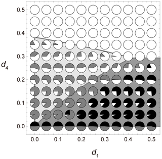

Figure 5. The *d*<sub>1</sub>-*d*<sub>4</sub> graph of the two-dimensional lattice-structured population.

The horizontal and vertical axes represent *d*<sub>1</sub> and *d*<sub>4</sub>, respectively. Each circle shows the average densities of sites occupied by either of the two strategies, as well as the empty sites (open circles) after 10,000 iterations in 100 simulations on the two-dimensional lattice. The black and gray portions of each circle indicate the average density of the sites occupied by colonies undertaking the 2∶2 division and 1∶3 division strategies, respectively. The open portion represents the average density of the empty sites. The lines in the graphs delineate the theoretical solutions in a completely mixed population. In the dark gray area, the 2∶2 division strategy theoretically wins over the 1∶3 strategy. In the light gray area, the predicted winning strategy is 1∶3. In *d*<sub>4</sub> = 0.0, mature colonies always survive and a neutral relationship develops between the strategies, which then coexist. Initial densities are *z*<sub>0</sub> = 0.2 and *x*<sub>1</sub> = *x*<sub>2</sub> = *x*<sub>3</sub> = *x*<sub>4</sub> = *y*<sub>1</sub> = *y*<sub>2</sub> = *y*<sub>3</sub> = *y*<sub>4</sub> = 0.1. The other parameters are: 2,500 lattice sites, *u* = 0 and *h* = 1. The death probability assumes death type (i).

https://doi.org/10.1371/journal.pone.0091210.g005

When all of *g*<sub>1</sub>, *g*<sub>2</sub>, and *g*<sub>3</sub> are less than one, the lattice-structured population displays logistic growth, which favors the 2∶2 short strategy over the 1∶3 long (see Figure S2).

Furthermore, if competition is introduced among all four division/dispersal strategies, colonies adopting either short-distance strategy rapidly become extinct because competition strongly favors long dispersal distance. After just a few iterations, the population comprises colonies adopting the 1∶3 long strategy and the 2∶2 long strategy. Since the 1∶3 and 2∶2 long-dispersing colonies in the lattice-structured population behave identically to their counterparts adopting the 1∶3 and the 2∶2 division strategies in the completely mixed population, the final competition outcomes among all four division/dispersal strategies are those of the 1∶3 and the 2∶2 division strategies in the completely mixed population (see Figure S3).

We now introduce two parameters of environmental disturbance, *u* and *q*, defined as the frequency of disturbance and the disturbance scale, respectively [17]. These parameters are independent of the baseline natural death. *q* can be interpreted as the degree of spatial autocorrelation. The probability that a colony of size *i* is removed from a site by environmental disturbance (leaving the previously occupied site empty) is defined as *u<sub>i</sub>* (0.0<sub>≤</sub>*u<sub>i</sub>*<sub>≤</sub>1.0). Disturbance is assumed independent of colony size and density (*u*<sub>1</sub> = *u*<sub>2</sub> = *u*<sub>3</sub> = *u*<sub>4</sub> = *u*). A disturbance kills a colony occupying a lattice site with probability *u*. The disturbance then spreads to a nearest neighbor site (selected randomly among eight neighbors) with probability *q* and kills the residential colony (if present). If the site is unoccupied, it is merely disturbed. The disturbance is repeated with probability *q* until halted with probability 1 – *q*. For example, if *u* is low and *q* is high, the lattice contains a few large or clustered disturbed areas. If *u* is high and *q* is low, many small areas are disturbed in the lattice.

Details are provided in the caption to Figure 5. The death probability assumes death type (i). (A) *d*<sub>1</sub> = 0.25 and *d*<sub>2</sub> = 0.15, (B) *d*<sub>1</sub> = 0.3 and *d*<sub>2</sub> = 0.15, (C) *d*<sub>1</sub> = 0.35 and *d*<sub>2</sub> = 0.15, (D) *d*<sub>1</sub> = 0.4 and *d*<sub>2</sub> = 0.15, (E) *d*<sub>1</sub> = 0.35 and *d*<sub>2</sub> = 0.1 and (F) *d*<sub>1</sub> = 0.35 and *d*<sub>2</sub> = 0.2. Other parameters are: *g*<sub>1</sub> = *g*<sub>2</sub> = *g*<sub>3</sub> = 1 and *h* = 1.

https://doi.org/10.1371/journal.pone.0091210.g006

## Discussion and Conclusions

We examined the ecological conditions under which budding can be advantageous over migration in colonial organisms. The main conclusions are summarized as follows: (1) when the life history parameters are independent of colony size, budding colonies are overwhelmed by dispersive colonies. (2) When the death probability of the smallest colonies is relatively higher than that of more mature colonies, survival favors the budding strategy. The death function can be modeled as a negative exponential function of the continuous lifespan. (3) Budding wins against dispersal when the growth rates of size 1 and size 3 colonies are lower than that of size 2 colonies. In this scenario, colonies undergo logistic growth, which ensures their survival if they adopt the budding strategy. (4) When a newly-divided dispersing colony does not compete with a settled colony for space, but instead colonizes open spaces, the budding strategy is advantageous over dispersal. This corresponds to the situation in which founding colonies leave their natal site, and seek and settle at a nearby open space.

We then examine the effects of spatial structure and environmental disturbance on the population dynamics. Relative to dispersal, the budding strategy proved less favorable in spatial structured populations than in completely mixed populations. This occurs because long distance dispersal prevents local overcrowding. In the event of environmental disturbance, long distance dispersal confers a survival advantage over budding species because migrating species can escape the risk. However, when the scale of environmental disturbance is small, budding can retain an advantage even under relatively high frequency of environmental disturbance.

Our current paper roughly supports the main results presented in Nakamaru *et al*. (2007). Among the various growth and death functions, logistic colony growth (corresponding to *g*<sub>1</sub>, *g*<sub>3</sub><*g*<sub>2</sub>) and an exponentially decreasing death function (corresponding to *d*<sub>1</sub>>>*d*<sub>2</sub>, *d*<sub>3</sub>, *d*<sub>4</sub>) favor budding over dispersal. However, the assumptions of our current model differ from those in Nakamaru et al (2007). For example, the previous study assumed continuous colony size, and that each colony obeys logistic growth and an exponentially decreasing death function. Here, to more easily investigate the effect of different growth and death functions on the evolutionary population dynamics, we discretized the colony size. Despite these differences in model assumptions, the results are consistent between the two studies, which strengthens our conclusions.

Budding likely evolves when very small individuals (or colonies) undergo logistic growth and are subject to relatively high mortality. Furthermore, our models suggest that budding is favored when dispersing offspring (colonies) can seek unoccupied spaces in which to settle without inciting conflict. Ant or coral colonies (or colonies of ramets in plants) usually exhibit type III survivorship curves (negative exponential mortality functions) [21]–[23] and logistic growth [21], [24]–[26]. Furthermore, ants are known to seek suitable empty sites when their colony disperses [27], [28]. Thus, these organisms are naturally predisposed to budding. Although our results also suggest that environmental disturbance promotes long-dispersing by its risk hedging effect and discourages budding, the benefits of budding may outweigh the disadvantage of short-distance dispersal in some of the above mentioned organisms (some corals, plants and ants) that reproduce by budding in frequently disturbed environments.

Rigorous empirical testing of our hypothesis is limited by the difficulty of distinguishing the baseline death and growth rates from the changes in those parameters induced by disturbance. However, we consider that our model predictions could be tested on realized average death and growth rates that include both baseline and additional (or reduced) rates caused by disturbance. As already mentioned, life history parameters such as survival and growth functions appear to directly determine which strategy should evolve. If the average death and growth rates of fission-dividing colonial organisms fulfill the predicted conditions favoring the 2∶2 division strategy described in Figure 2 and Eqs. (4) and (6), our models would be supported. The life history of species or closely related species adopting both budding and non-budding tactics must be investigated in empirical studies.

Previous studies on the evolution of body-condition dependency in dispersal have not directly addressed the budding phenomenon [29]–[31]. Instead, these models assume semelparity or an annual lifecycle. Budding is possible only when a parent (or part of the parent's body) survives after reproduction, coexists with the offspring (perennial) and re-reproduces (iteroparity). Therefore, our results are not directly comparable with the results of these studies.

We now discuss the factors that should be incorporated into our current model to render it more realistic. We assumed that a colony reproduces by dividing in two. We also assumed that (not always, however) large offspring disperse over a smaller distance (size-dispersal distance trade off). However, another reproductive constraint has been reported in the literature; the trade-off between size and number of offspring (e.g. [32]). We consider that the size-number trade-off is a sensible proposition when the parental effort or total parental resource that can be allocated to reproduction is constant. For generality in our current study, the total reproductive effort was assumed labile (for instance, the dispersive strategy (3∶1 strategy) invests more resource in survival than budding, given that the dispersed portion is the offspring). We now introduce the 2∶1∶1: division strategy, in which a size 4 colony divides into one size 2 colony and two size 1 colonies that then disperse, and the 1∶1∶1∶1 division strategy, in which a size 4 colony divides into four size 1 colonies. We constrained the reproduction effort to be constant (mimicking a size–number trade off) in the competition between 2∶1∶1 vs. 2∶2 strategies. However, biological strategies might be more precisely described by 2∶1∶1 and 1∶1∶1∶1 strategies; for example; plants may release many seeds and ant colonies disperse many winged queens simultaneously. We have partially tackled this situation. In well-mixed populations, the local stable conditions of the 1∶1∶1∶1 and the 2∶1∶1 division strategies are 4*p*<sub>1</sub>*p*<sub>2</sub>*p*<sub>3</sub> > *p*<sub>4</sub> + (1−*p*<sub>4</sub>)/*h* and *p*<sub>2</sub>*p*<sub>3</sub>(1+2*p*<sub>1</sub>) > *p*<sub>4</sub> + (1−*p*<sub>4</sub>)/*h*, respectively (method presented in the Appendices). The left hand side of both inequalities specifies the probability that dividing colonies mature to size 4. This result implies that (i) budding wins against the other three strategies when the survival probability of size 1 colonies (*p*<sub>1</sub>) is very small, and (ii) if the converse is true (*p*<sub>1</sub> is high), the 1∶1∶1∶1 division strategy may be favored. The latter condition might simulate the evolution of semelparity. However, the strongest strategy when members of the population adopt all four strategies has yet to be elucidated.Furthermore, one must consider relaxing the assumption on the timing of reproduction. Size 4 colonies only reproduce in the current model. If we assume that size 2 and 3 colonies can reproduce, we can analyze the conditions under which annual or perennial life cycles evolve (regarding the reproductive strategy of size 2 colonies as annual semelparity).

The current model does not include colony size effects in disturbance. For instance, if smaller colonies are more vulnerable to environmental disturbance than larger ones, the budding might be more advantageous over dispersal than is predicted in this paper. Finally, our study considers neither explicit competition among individuals within each colony nor direct interference induced by competition between neighboring colonies. In future work, we will incorporate these factors into a more realistic model.

Budding has been considered to play a key role in evolutionary ecology. Theoretically, budding increases the genetic variance among groups and/or the genetic relatedness within groups, thus promoting the evolution of group-advantageous traits such as altruism and female-biased sex allocation [33]–[35]. On the other hand, restricted migration (which frequently accompanies fission) intensifies the local competition among related individuals and hinders the evolution of altruism, despite the apparent enhancement of genetic relatedness of interactants [36]–[38]. However, recent theoretical and empirical studies suggest that budding can solve this “viscous population dilemma” and enable the evolution of altruism, because budding increases the number of more related individuals in the background local population [7], [8], [39]–[45]. All of the above-mentioned theoretical studies focus on the effect of budding on evolved social traits. Thus, budding is assumed as the given condition, without considering the environments in which budding evolves. The latter problem is the focus of our current paper. On the other hand, the ecological life history models introduced here neglect issues such as relatedness and intra-colonial conflicts. Therefore, our current study is complementary to existing studies. In future studies, we hope to incorporate relatedness and intra-colonial conflicts into the model scheme, to better understand the ecological drivers of coevolving life history and social traits.

## Supporting Information

Ecological Conditions Favoring Budding in Colonial Organisms under Environmental Disturbance

Showing 1/8: Figure_S1.tif

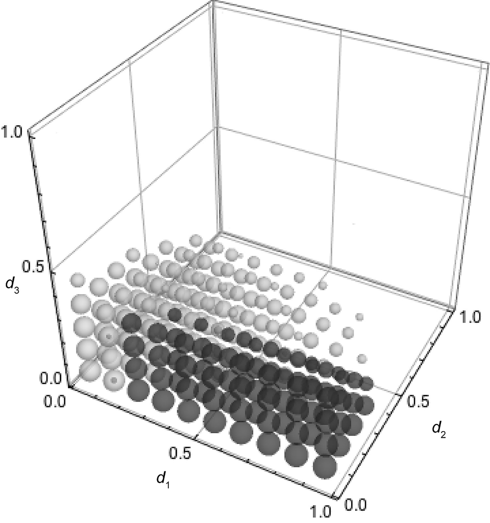

### [Figure S1.](https://journals.plos.org/plosone/article/file?type=supplementary&id=info:doi/10.1371/journal.pone.0091210.s001)

**Effect of life history parameters on competition between the two strategies in the two-dimensional lattice.** Black spheres indicate that the 2∶2 short strategy overcomes the 1∶3 long strategy, while gray spheres indicate the opposite. Where no spheres are presented, colonies have become extinct. The volume of each sphere denotes the average density of the strategy after 1,000 iterations. This graph shows the effect of imposing the death probabilities *d*<sub>1</sub>, *d*<sub>2</sub>, *d*<sub>3</sub>. The parameters are *d*<sub>4</sub> = 0.2, *g*<sub>1</sub> = *g*<sub>2</sub> = *g*<sub>3</sub> = 1, *h* = 1. Initial densities are *z*<sub>0</sub> = 0.6 and *x*<sub>1</sub> = *x*<sub>2</sub> = *x*<sub>3</sub> = *x*<sub>4</sub> = *y*<sub>1</sub> = *y*<sub>2</sub> = *y*<sub>3</sub> = *y*<sub>4</sub> = 0.05.

https://doi.org/10.1371/journal.pone.0091210.s001

(TIF)

### [Figure S2.](https://journals.plos.org/plosone/article/file?type=supplementary&id=info:doi/10.1371/journal.pone.0091210.s002)

**Effect of life history parameters on competition between the two strategies in the two-dimensional lattice.** Black spheres indicate that the 2∶2 short strategy overcomes the 1∶3 long strategy, while gray spheres indicate the opposite. Where no spheres are presented, the colonies have become extinct. The volume of each sphere denotes the average density of the strategy after 6,250 iterations. This graph illustrates the effect of growth probabilities *g*<sub>1</sub>, *g*<sub>2</sub>, and *g*<sub>3</sub>. Other parameters are: *d*<sub>1</sub> = 0.35, *d*<sub>2</sub> = *d*<sub>3</sub> = *d*<sub>4</sub> = 0.15. Initial densities are *z*<sub>0</sub> = 0.6 and *x*<sub>1</sub> = *x*<sub>2</sub> = *x*<sub>3</sub> = *x*<sub>4</sub> = *y*<sub>1</sub> = *y*<sub>2</sub> = *y*<sub>3</sub> = *y*<sub>4</sub> = 0.05.

https://doi.org/10.1371/journal.pone.0091210.s002

(TIF)

### [Figure S3.](https://journals.plos.org/plosone/article/file?type=supplementary&id=info:doi/10.1371/journal.pone.0091210.s003)

**Competition among four possible strategies in a structured population residing on a two dimensional lattice, after 10,000 iterations.** The parameters are *g*<sub>2</sub> = *g*<sub>3</sub>, *d*<sub>1</sub> = 0.35, *d*<sub>2</sub> = *d*<sub>3</sub> = *d*<sub>4</sub> = 0.15 and *h* = 1. The initial population density of each strategy is the same and the initial density of vacant sites is 0.6.

https://doi.org/10.1371/journal.pone.0091210.s003

(TIF)

### [Figure S4.](https://journals.plos.org/plosone/article/file?type=supplementary&id=info:doi/10.1371/journal.pone.0091210.s004)

**The** *u***-***q* **graph of colony-based simulations in the two-dimensional lattice structured population after 6,250 iterations.** Details are provided in the caption to Figure 5. (A) *g*<sub>1</sub> = 0.8 and *g*<sub>2</sub> = 0.8, (B) *g*<sub>1</sub> = 0.8 and *g*<sub>2</sub> = 0.6, (C) *g*<sub>1</sub> = 0.8 and *g*<sub>2</sub> = 0.4, (D) *g*<sub>1</sub> = 0.6 and *g*<sub>2</sub> = 0.8, (E) *g*<sub>1</sub> = 0.6 and *g*<sub>2</sub> = 0.6 and (F) *g*<sub>1</sub> = 0.6 and *g*<sub>2</sub> = 0.4. Other parameters are: *d*<sub>1</sub> = 0.35, *d*<sub>2</sub> = *d*<sub>3</sub> = *d*<sub>4</sub> = 0.15, *h* = 1 and *g*<sub>3</sub> = 0.9. Initial density of each size of each strategy is identical, and the initial density of vacant sites is 0.6.

https://doi.org/10.1371/journal.pone.0091210.s004

(TIF)

### [Appendix S1.](https://journals.plos.org/plosone/article/file?type=supplementary&id=info:doi/10.1371/journal.pone.0091210.s005)

**Corollary of Jury's criterion.**

https://doi.org/10.1371/journal.pone.0091210.s005

(DOC)

### [Appendix S2.](https://journals.plos.org/plosone/article/file?type=supplementary&id=info:doi/10.1371/journal.pone.0091210.s006)

**Local stability analysis of positive equilibrium on the 2**∶**2 division strategy.**

https://doi.org/10.1371/journal.pone.0091210.s006

(DOC)

### [Appendix S3.](https://journals.plos.org/plosone/article/file?type=supplementary&id=info:doi/10.1371/journal.pone.0091210.s007)

**Local stability analysis of positive equilibrium on the 1**∶**3 division strategy.**

https://doi.org/10.1371/journal.pone.0091210.s007

(DOC)

### [Appendix S4.](https://journals.plos.org/plosone/article/file?type=supplementary&id=info:doi/10.1371/journal.pone.0091210.s008)

**Local stability analysis in competitive system between two strategies.**

https://doi.org/10.1371/journal.pone.0091210.s008

(DOC)

## Acknowledgments

We thank Evan Economo for his helpful comments.

## Author Contributions

Conceived and designed the experiments: MN. Performed the experiments: AO SUS KM. Analyzed the data: AO SUS KM MN. Wrote the paper: MN TT KT. Made the mathematical model: MN. Proved the mathematical model: TT. Analyzed the mathematical model: TT MN.

## References

1. 1. Clobert J, Danchin E, Dhonde AA, Nichols JD (2001) Dispersal. Oxford: Oxford University Press.
2. 2. Levin SA, Muller-Landau HC, Nathan R, Chave J (2003) The ecology and evolution of seed dispersal: A theoretical perspective. Annu Rev Ecol Syst 34: 575–604.
   - View Article
   - [Google Scholar](http://scholar.google.com/scholar?q=The+ecology+and+evolution+of+seed+dispersal%3A+A+theoretical+perspective+Levin+2003)
3. 3. Clobert J, Baguette M, Benton TG, Bullock JM (2012) Dispersal ecology and evolution. Oxford: Oxford University Press.
4. 4. Wynee-Edwards V (1962) Animal dispersion in relation to social behaviour. New York: Hafaer.
5. 5. Williams GC (1966) Adaptation and natural selection. Princeton: Princeton University Press.
6. 6. Ronce O, Olivieri I, Clobert J, Danchin E (2001) Perspectives on the study of dispersal evolution. In: Clobert J, Danchin E, Dhonde AA, Nichols JD, editors. Dispersal. Oxford: Oxford University Press. pp. 341–357.
7. 7. Gardner A, West SA (2006) Demography, altruism, and the benefits of budding. J Evol Biol 19: 1707–1716.
   - View Article
   - [Google Scholar](http://scholar.google.com/scholar?q=Demography%2C+altruism%2C+and+the+benefits+of+budding+Gardner+2006)
8. 8. Kummerli R, Gardner A, West SA, Griffin AS (2009) Limited dispersal, budding dispersal, and cooperation: an experimental study. Evolution 63: 939–949.
   - View Article
   - [Google Scholar](http://scholar.google.com/scholar?q=Limited+dispersal%2C+budding+dispersal%2C+and+cooperation%3A+an+experimental+study+Kummerli+2009)
9. 9. Gardner A, Arce A, Alpedrinha J (2009) Budding dispersal and the sex ratio. Journal of Evolutionary Biology 22: 1036–1045.
   - View Article
   - [Google Scholar](http://scholar.google.com/scholar?q=Budding+dispersal+and+the+sex+ratio+Gardner+2009)
10. 10. Liu J, Dong M, Miao SL, Li ZY, Song MH, et al. (2006) Invasive alien plants in China: role of clonality and geographical origin. Biol Invasions 8: 1461–1470.
    - View Article
    - [Google Scholar](http://scholar.google.com/scholar?q=Invasive+alien+plants+in+China%3A+role+of+clonality+and+geographical+origin+Liu+2006)
11. 11. Honnay O, Jacquemyn H (2010) Clonal plants: beyond the patterns—ecological and evolutionary dynamics of asexual reproduction. Evol Ecol 24: 1393–1397.
    - View Article
    - [Google Scholar](http://scholar.google.com/scholar?q=Clonal+plants%3A+beyond+the+patterns%E2%80%94ecological+and+evolutionary+dynamics+of+asexual+reproduction+Honnay+2010)
12. 12. Coffroth MA, Lasker HR (1998) Population structure of a clonal gorgonian coral: The interplay between clonal reproduction and disturbance. Evolution 52: 379–393.
    - View Article
    - [Google Scholar](http://scholar.google.com/scholar?q=Population+structure+of+a+clonal+gorgonian+coral%3A+The+interplay+between+clonal+reproduction+and+disturbance+Coffroth+1998)
13. 13. Passera L (1994) Characteristics of tramp species. In: William DF, editor. Exotic ants: biology, impact, and control of introduced species. Colorado: Westview Press. pp. 23–43.
14. 14. Holway DA, Lach L, Suarez AV, Tsutsui ND, Case TJ (2002) The causes and consequences of ant invasions. Annu Rev Ecol Syst 33: 181–233.
    - View Article
    - [Google Scholar](http://scholar.google.com/scholar?q=The+causes+and+consequences+of+ant+invasions+Holway+2002)
15. 15. Carpintero S, Reyes-Lopez J, de Reyna LA (2003) Impact of human dwelling on the distribution of the exotic Argentine ant: a case study in the Doñana National Park. Biol Conserv 115: 279–289.
    - View Article
    - [Google Scholar](http://scholar.google.com/scholar?q=Impact+of+human+dwelling+on+the+distribution+of+the+exotic+Argentine+ant%3A+a+case+study+in+the+Do%C3%B1ana+National+Park+Carpintero+2003)
16. 16. Tsuji K (2010) Unicolonial ants: loss of colony identity. In: Breed M, Moore J, editors. Encyclopedia of Animal Behavior. Oxford: Academic Press. pp. 469–473.
17. 17. Nakamaru M, Beppu Y, Tsuji K (2007) Does disturbance favor dispersal? An analysis of ant migration using the colony-based lattice model. J Theor Biol 248: 288–300.
    - View Article
    - [Google Scholar](http://scholar.google.com/scholar?q=Does+disturbance+favor+dispersal%3F+An+analysis+of+ant+migration+using+the+colony-based+lattice+model+Nakamaru+2007)
18. 18. Caswell H (2000) Matrix population models 2nd edition. Sunderland: Sinauer Associates, Inc., Publishers.
19. 19. Stearns SC (1992) The Evolution of Life Histories. Oxford: Oxford University Press.
20. 20. Gardner A, Grafen A (2009) Capturing the superorganism: a formal theory of group adaptation. J Evol Biol 22: 659–671.
    - View Article
    - [Google Scholar](http://scholar.google.com/scholar?q=Capturing+the+superorganism%3A+a+formal+theory+of+group+adaptation+Gardner+2009)
21. 21. Hölldobler B, Wilson EO (1990) The ants. Cambridge: Belknap Press of Harvard University Press.
22. 22. Babcock RC (1991) Comparative demography of three species of scleractinian corals using age- and size-dependent classifications. Ecol Monogr 61: 225–244.
    - View Article
    - [Google Scholar](http://scholar.google.com/scholar?q=Comparative+demography+of+three+species+of+scleractinian+corals+using+age-+and+size-dependent+classifications+Babcock+1991)
23. 23. Harper JL (1977) Population Biology of Plants. Waltham: Academic Press.
24. 24. Yamaguchi M (1983) Growth data analysis in the reef-building coral {Pocillopora} {damicornis} (Linnaeus). Galaxea 2: 21–27.
    - View Article
    - [Google Scholar](http://scholar.google.com/scholar?q=Growth+data+analysis+in+the+reef-building+coral+%7BPocillopora%7D+%7Bdamicornis%7D+%28Linnaeus%29+Yamaguchi+1983)
25. 25. van Woesik R, Sakai K, Ganase A, Loya Y (2011) Revisiting the winners and the losers a decade after coral bleaching. Mar Ecol Prog Ser 434: 67–76.
    - View Article
    - [Google Scholar](http://scholar.google.com/scholar?q=Revisiting+the+winners+and+the+losers+a+decade+after+coral+bleaching+van+Woesik+2011)
26. 26. Suzuki JI, Hucthings MJ (1997) Interactions between shoots in clonal plants and the effects of stored resources on the structure of shoot population. In: de Kroon H, van Groenendael J, editors. The Ecology and Evolution of Clonal Plants. Leiden: Backhuys Publishers.
27. 27. Stroeymeyt N, Giurfa M, Franks NR (2010) Improving decision speed, accuracy and group cohesion through early information gathering in house-hunting ants. PLoS One 5: e13059.
    - View Article
    - [Google Scholar](http://scholar.google.com/scholar?q=Improving+decision+speed%2C+accuracy+and+group+cohesion+through+early+information+gathering+in+house-hunting+ants+Stroeymeyt+2010)
28. 28. Cronin AL (2012) Consensus decision making in the ant Myrmecina nipponica: house-hunters combine pheromone trails with quorum responses. Anim Behav 84: 1243–1251.
    - View Article
    - [Google Scholar](http://scholar.google.com/scholar?q=Consensus+decision+making+in+the+ant+Myrmecina+nipponica%3A+house-hunters+combine+pheromone+trails+with+quorum+responses+Cronin+2012)
29. 29. Gyllenberg M, Kisdi E, Utz M (2008) Evolution of condition-dependent dispersal under kin competition. J Math Biol 57: 285–307.
    - View Article
    - [Google Scholar](http://scholar.google.com/scholar?q=Evolution+of+condition-dependent+dispersal+under+kin+competition+Gyllenberg+2008)
30. 30. Gyllenberg M, Kisdi E, Utz M (2011) Body condition dependent dispersal in a heterogeneous environment. Theor Popul Biol 79: 139–154.
    - View Article
    - [Google Scholar](http://scholar.google.com/scholar?q=Body+condition+dependent+dispersal+in+a+heterogeneous+environment+Gyllenberg+2011)
31. 31. Gyllenberg M, Kisdi E, Utz M (2011) Variability within families and the evolution of body-condition-dependent dispersal. J Biol Dyn 5: 191–211.
    - View Article
    - [Google Scholar](http://scholar.google.com/scholar?q=Variability+within+families+and+the+evolution+of+body-condition-dependent+dispersal+Gyllenberg+2011)
32. 32. Smith CC, Fretwell SD (1974) The optimal balance between size and number of offspring. Am Nat 108: 499–506.
    - View Article
    - [Google Scholar](http://scholar.google.com/scholar?q=The+optimal+balance+between+size+and+number+of+offspring+Smith+1974)
33. 33. Slatkin M, Wade MJ (1978) Group selection on a quantitative character. Proc Natl Acad Sci U S A 75: 3531–3534.
    - View Article
    - [Google Scholar](http://scholar.google.com/scholar?q=Group+selection+on+a+quantitative+character+Slatkin+1978)
34. 34. Goodnight CJ, Stevens L (1997) Experimental studies of group selection: what do they tell us about group selection in nature? Am Nat 150: S59–S79.
    - View Article
    - [Google Scholar](http://scholar.google.com/scholar?q=Experimental+studies+of+group+selection%3A+what+do+they+tell+us+about+group+selection+in+nature+Goodnight+1997)
35. 35. Ono S, Misawa K, Tsuji K (2003) Effect of Group Selection on the Evolution of Altruistic Behavior. J Theor Biol 220: 55–66.
    - View Article
    - [Google Scholar](http://scholar.google.com/scholar?q=Effect+of+Group+Selection+on+the+Evolution+of+Altruistic+Behavior+Ono+2003)
36. 36. Wilson DS, Pollock GB, Dugatkin LA (1992) Can sltruism evolve in purely viscous populations? Evol Ecol 6: 331–341.
    - View Article
    - [Google Scholar](http://scholar.google.com/scholar?q=Can+sltruism+evolve+in+purely+viscous+populations+Wilson+1992)
37. 37. Taylor PD (1992) Altruism in viscous populations - an inclusive fitness model. Evol Ecol 6: 352–356.
    - View Article
    - [Google Scholar](http://scholar.google.com/scholar?q=Altruism+in+viscous+populations+-+an+inclusive+fitness+model+Taylor+1992)
38. 38. Taylor PD (1992) Inclusive fitness in a homogeneous environment. Proc Biol Sci 249: 299–302.
    - View Article
    - [Google Scholar](http://scholar.google.com/scholar?q=Inclusive+fitness+in+a+homogeneous+environment+Taylor+1992)
39. 39. Sharp SP, Simeoni M, Hatchwell BJ (2008) Dispersal of sibling coalitions promotes helping among immigrants in a cooperatively breeding bird. Proc Biol Sci 275: 2125–2130.
    - View Article
    - [Google Scholar](http://scholar.google.com/scholar?q=Dispersal+of+sibling+coalitions+promotes+helping+among+immigrants+in+a+cooperatively+breeding+bird+Sharp+2008)
40. 40. Slatkin M (1977) Gene flow and genetic drift in a species subject to frequent local extinctions. Theor Popul Biol 12: 253–262.
    - View Article
    - [Google Scholar](http://scholar.google.com/scholar?q=Gene+flow+and+genetic+drift+in+a+species+subject+to+frequent+local+extinctions+Slatkin+1977)
41. 41. Goodnight KT (1992) The effect of stochastic variation on kin selection in a budding-viscous population. Am Nat 140: 1028–1040.
    - View Article
    - [Google Scholar](http://scholar.google.com/scholar?q=The+effect+of+stochastic+variation+on+kin+selection+in+a+budding-viscous+population+Goodnight+1992)
42. 42. Lehmann L, Perrin N, Rpusset F (2006) Population demography and the evolution of helping behaviors. Evolution 60: 1137–1151.
    - View Article
    - [Google Scholar](http://scholar.google.com/scholar?q=Population+demography+and+the+evolution+of+helping+behaviors+Lehmann+2006)
43. 43. Bradley BJ, Doran-Sheehy DM, Vigilant L (2007) Potential for female kin associations in wild western gorillas despite female dispersal. Proc Biol Sci 274: 2179–2185.
    - View Article
    - [Google Scholar](http://scholar.google.com/scholar?q=Potential+for+female+kin+associations+in+wild+western+gorillas+despite+female+dispersal+Bradley+2007)
44. 44. Heinsohn R, Dunn P, Leggs S, Double M (2000) Coalitions of relatives and reproductive skew in cooperatively breeding white-winged choughs. Proc Biol Sci 267: 243–249.
    - View Article
    - [Google Scholar](http://scholar.google.com/scholar?q=Coalitions+of+relatives+and+reproductive+skew+in+cooperatively+breeding+white-winged+choughs+Heinsohn+2000)
45. 45. Williams DA, Rabenold KN (2004) Male-biased dispersal, female philopatry, and routes to fitness in a social corvid. J Anim Ecol 74: 150–159.
    - View Article
    - [Google Scholar](http://scholar.google.com/scholar?q=Male-biased+dispersal%2C+female+philopatry%2C+and+routes+to+fitness+in+a+social+corvid+Williams+2004)

[figure not shown]